# Bayesian Networks Assignment 2

# Setup

Utility File

```r
source("utilities_ass2.R")
```

Packages

```r
# Install bnlearn
if (!require(bnlearn)){
  install.packages("bnlearn")
}

if (!require(pcalg)){
  install.packages("pcalg")
}

if (!require(MatchIt)){
  install.packages("MatchIt")
}

if (!require(stddiff)){
  install.packages("stddiff")
}

if (!require(forestplot)){
  install.packages("forestplot")
}

library(forestplot)
library(stddiff)
library(MatchIt)
library(pcalg)
library(igraph)
#library(bnlearn)
```

Load and preprocess data

```r
# Load data
d <- read.csv("diabetes_binary_health_indicators_BRFSS2015.csv")


# Ordinal Variables
d$GenHlth <- factor(d$GenHlth, levels = 1:5, ordered = TRUE)
#d$Age <- factor(d$Age, levels = 1:13, ordered = TRUE)
d$Education <- factor(d$Education, levels = 1:6, ordered = TRUE)
d$Income <- factor(d$Income, levels = 1:8, ordered = TRUE)
d$Age <- as.numeric(d$Age)

# Convert numeric variables to ordinal because PC algorithm needs all discrete
# data for using the disCItest.
d$BMI <- cut(d$BMI, breaks=4, labels = FALSE)
d$MentHlth <- cut(d$MentHlth, breaks=4, labels = FALSE)
d$PhysHlth <- cut(d$PhysHlth, breaks=4, labels = FALSE)
d$Age <- cut(d$Age, breaks=4, labels = FALSE)


# Preprocess the data to make it all numeric
preprocess_data <- function(d) {
  d_processed <- d

  # Convert all ordinal factors to numeric (integer levels)
  for (col in names(d_processed)) {
    if (is.ordered(d_processed[[col]])) {
      d_processed[[col]] <- as.numeric(d_processed[[col]])
    }
  }

  # Ensure all numeric columns are integers (for discrete tests)
  for (col in names(d_processed)) {
    if (is.numeric(d_processed[[col]]) || is.integer(d_processed[[col]])) {
      d_processed[[col]] <- as.integer(d_processed[[col]])
    }
  }

  return(d_processed)
}

# Apply preprocessing
d_processed <- preprocess_data(d)

# Verify the structure of the processed data
str(d_processed)
```

```
'data.frame':   253680 obs. of  22 variables:
 $ Diabetes_binary     : int  0 0 0 0 0 0 0 0 1 0 ...
 $ HighBP              : int  1 0 1 1 1 1 1 1 1 0 ...
 $ HighChol            : int  1 0 1 0 1 1 0 1 1 0 ...
 $ CholCheck           : int  1 0 1 1 1 1 1 1 1 1 ...
 $ BMI                 : int  2 1 1 1 1 1 1 1 1 1 ...
 $ Smoker              : int  1 1 0 0 0 1 1 1 1 0 ...
 $ Stroke              : int  0 0 0 0 0 0 0 0 0 0 ...
 $ HeartDiseaseorAttack: int  0 0 0 0 0 0 0 0 1 0 ...
 $ PhysActivity        : int  0 1 0 1 1 1 0 1 0 0 ...
 $ Fruits              : int  0 0 1 1 1 1 0 0 1 0 ...
 $ Veggies             : int  1 0 0 1 1 1 0 1 1 1 ...
 $ HvyAlcoholConsump   : int  0 0 0 0 0 0 0 0 0 0 ...
 $ AnyHealthcare       : int  1 0 1 1 1 1 1 1 1 1 ...
 $ NoDocbcCost         : int  0 1 1 0 0 0 0 0 0 0 ...
 $ GenHlth             : int  5 3 5 2 2 2 3 3 5 2 ...
 $ MentHlth            : int  3 1 4 1 1 1 1 1 4 1 ...
 $ PhysHlth            : int  2 1 4 1 1 1 2 1 4 1 ...
 $ DiffWalk            : int  1 0 1 0 0 0 0 1 1 0 ...
 $ Sex                 : int  0 0 0 0 0 1 0 0 0 1 ...
 $ Age                 : int  3 2 3 4 4 3 3 4 3 3 ...
 $ Education           : int  4 6 4 3 5 6 6 4 5 4 ...
 $ Income              : int  3 1 8 6 4 8 7 4 1 3 ...
```

```r
integer_cols <- sapply(d_processed, is.integer)
for (col in names(d_processed)[integer_cols]) {
  d_processed[[col]] <- as.factor(d_processed[[col]])
}
str(d_processed)
```

```
'data.frame':   253680 obs. of  22 variables:
 $ Diabetes_binary     : Factor w/ 2 levels "0","1": 1 1 1 1 1 1 1 1 2 1 ...
 $ HighBP              : Factor w/ 2 levels "0","1": 2 1 2 2 2 2 2 2 2 1 ...
 $ HighChol            : Factor w/ 2 levels "0","1": 2 1 2 1 2 2 1 2 2 1 ...
 $ CholCheck           : Factor w/ 2 levels "0","1": 2 1 2 2 2 2 2 2 2 2 ...
 $ BMI                 : Factor w/ 4 levels "1","2","3","4": 2 1 1 1 1 1 1 1 1 1 ...
 $ Smoker              : Factor w/ 2 levels "0","1": 2 2 1 1 1 2 2 2 2 1 ...
 $ Stroke              : Factor w/ 2 levels "0","1": 1 1 1 1 1 1 1 1 1 1 ...
 $ HeartDiseaseorAttack: Factor w/ 2 levels "0","1": 1 1 1 1 1 1 1 1 2 1 ...
 $ PhysActivity        : Factor w/ 2 levels "0","1": 1 2 1 2 2 2 1 2 1 1 ...
 $ Fruits              : Factor w/ 2 levels "0","1": 1 1 2 2 2 2 1 1 2 1 ...
 $ Veggies             : Factor w/ 2 levels "0","1": 2 1 1 2 2 2 1 2 2 2 ...
 $ HvyAlcoholConsump   : Factor w/ 2 levels "0","1": 1 1 1 1 1 1 1 1 1 1 ...
 $ AnyHealthcare       : Factor w/ 2 levels "0","1": 2 1 2 2 2 2 2 2 2 2 ...
 $ NoDocbcCost         : Factor w/ 2 levels "0","1": 1 2 2 1 1 1 1 1 1 1 ...
 $ GenHlth             : Factor w/ 5 levels "1","2","3","4",..: 5 3 5 2 2 2 3 3 5 2 ...
 $ MentHlth            : Factor w/ 4 levels "1","2","3","4": 3 1 4 1 1 1 1 1 4 1 ...
 $ PhysHlth            : Factor w/ 4 levels "1","2","3","4": 2 1 4 1 1 1 2 1 4 1 ...
 $ DiffWalk            : Factor w/ 2 levels "0","1": 2 1 2 1 1 1 1 2 2 1 ...
 $ Sex                 : Factor w/ 2 levels "0","1": 1 1 1 1 1 2 1 1 1 2 ...
 $ Age                 : Factor w/ 4 levels "1","2","3","4": 3 2 3 4 4 3 3 4 3 3 ...
 $ Education           : Factor w/ 6 levels "1","2","3","4",..: 4 6 4 3 5 6 6 4 5 4 ...
 $ Income              : Factor w/ 8 levels "1","2","3","4",..: 3 1 8 6 4 8 7 4 1 3 ...
```

```r
ci.test("Age", "DiffWalk", "BMI", data = d_processed, test="x2")
```

```
    Pearson's X^2

data:  Age ~ DiffWalk | BMI
x2 = 11456, df = 12, p-value < 2.2e-16
alternative hypothesis: true value is greater than 0
```

# Part 1: PC Algorithm

Run pc algorithm

```r
var_names <- colnames(d_processed)  # Get variable names from your dataset
p <- length(var_names)

fixedEdges <- matrix(FALSE, nrow = p, ncol = p, dimnames = list(var_names, var_names))
fixedEdges["HighBP", "Diabetes_binary"] <- TRUE
fixedEdges["Diabetes_binary", "HighBP"] <- TRUE  # Symmetric


# Sample a subset to speed up algorithm
d_sampled <- d_processed[sample(1:nrow(d_processed), size = 10000), ]

suffStat <-list(dm = as.matrix(d_sampled), nlev = apply(d_sampled, 2, function(x) length(unique(x))), adaptDF = FALSE)

fit <- pc(suffStat =  suffStat,
          indepTest = disCItest,
          # 0.05 good
          # 0.0001 also good?
          alpha = 0.1,
          labels = colnames(d),
          m.max = 2,
          skel.method = "stable.fast",
          numCores = 16,
          fixedEdges = fixedEdges,
          u2pd = "retry",
          verbose = TRUE)
```

[output not shown]

[output cut: 7238 more lines]

[output not shown]

```r
is_valid <- isValidGraph(as(fit, "amat"), type = "cpdag")
print(is_valid)
```

```
[1] TRUE
```

Plot

```r
# Load the necessary libraries
library(pcalg)
library(dagitty)

# Assuming you already have a pcAlgo object named `pc_result`
# Extract adjacency matrix
adj_matrix <- as(fit@graph, "matrix")

# Extract node names from the pcAlgo object
node_names <- colnames(adj_matrix)  # Get node names from the adjacency matrix

# Convert adjacency matrix to an edge list with actual node names
edge_list <- which(adj_matrix == 1, arr.ind = TRUE)
edges <- apply(edge_list, 1, function(x) {
  paste0(node_names[x[1]], " -> ", node_names[x[2]])  # Use node names
})

# Create a DAGitty graph
dag <- dagitty(paste("dag {", paste(edges, collapse = "; "), "}"))

# Print the DAGitty object
print(dag)
```

```
dag {
Age
AnyHealthcare
BMI
CholCheck
Diabetes_binary
DiffWalk
Education
Fruits
GenHlth
HeartDiseaseorAttack
HighBP
HighChol
HvyAlcoholConsump
NoDocbcCost
PhysActivity
Sex
Smoker
Stroke
Veggies
Age -> HighBP
Age -> HighChol
Age -> Smoker
AnyHealthcare -> Age
AnyHealthcare -> CholCheck
AnyHealthcare -> NoDocbcCost
BMI -> HighBP
CholCheck -> AnyHealthcare
CholCheck -> Diabetes_binary
CholCheck -> HighBP
CholCheck -> HighChol
Diabetes_binary -> Age
Diabetes_binary -> BMI
Diabetes_binary -> GenHlth
Diabetes_binary -> HighBP
Diabetes_binary -> HighChol
DiffWalk -> Age
DiffWalk -> Diabetes_binary
DiffWalk -> GenHlth
DiffWalk -> HeartDiseaseorAttack
```

[output cut: 15 more lines]

```
HeartDiseaseorAttack -> Smoker
HeartDiseaseorAttack -> Stroke
HighBP -> GenHlth
HighBP -> Stroke
HighChol -> GenHlth
HighChol -> HighBP
HvyAlcoholConsump -> Diabetes_binary
HvyAlcoholConsump -> Smoker
NoDocbcCost -> AnyHealthcare
PhysActivity -> GenHlth
Sex -> Fruits
Sex -> HeartDiseaseorAttack
Sex -> Smoker
Veggies -> PhysActivity
}
```

```
Plot coordinates for graph not supplied! Generating coordinates, see ?coordinates for how to set your own.
```

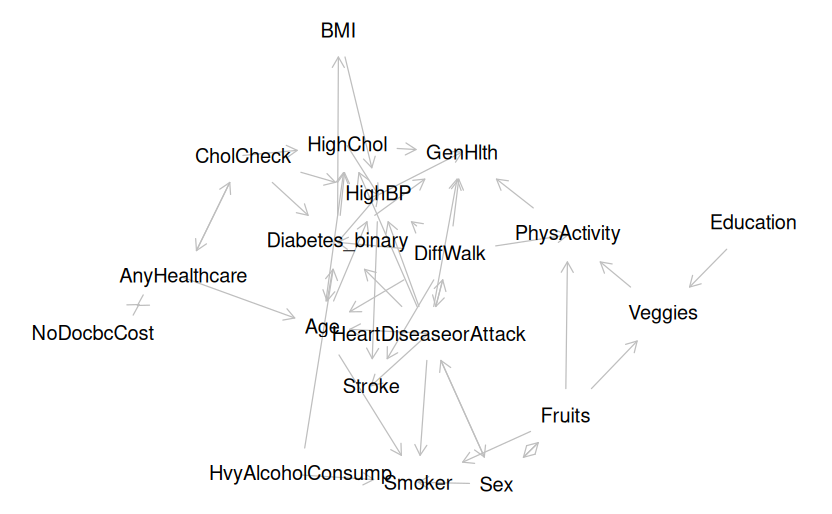

```r
# Plot the DAG
plot(dag)
```

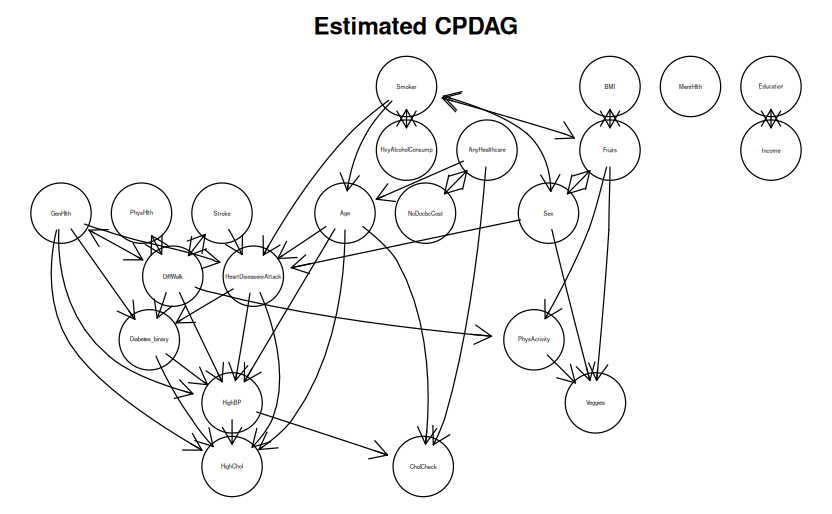

```r
library(Rgraphviz)
adj_matrix <- as(fit, "matrix")
graph <- as(adj_matrix, "graphNEL")
nodeRenderInfo(graph)$fontsize <- 20
#if (require(Rgraphviz)) {
   ## show estimated CPDAG
plot(fit, "twopi", main = "Estimated CPDAG")
```

```r
#}

#iplotPC(fit)
```

Check for cycles

```r
is_valid <- isValidGraph(as(fit, "amat"), type = "cpdag")
print(is_valid)
```

```
[1] TRUE
```

# Part 2: Propensity Score Matching

## Find Imbalances

```r
data <- load_data()
# Treat HighBP as a grouping varible ("Yes/No")
# data$HighBP <- as.factor(data$HighBP)

# Sample subset to avoid integer overflow in stddiff
data <- data[sample(1:nrow(data), size = 75000), ]
```

```r
summary(lm(Diabetes_binary ~ HighBP, data))
```

```
Call:
lm(formula = Diabetes_binary ~ HighBP, data = data)

Residuals:
     Min       1Q   Median       3Q      Max
-0.24540 -0.24540 -0.06126 -0.06126  0.93874

Coefficients:
            Estimate Std. Error t value Pr(>|t|)
(Intercept) 0.061263   0.001616   37.90   <2e-16 ***
HighBP      0.184132   0.002471   74.51   <2e-16 ***
---
Signif. codes:  0 ‘***’ 0.001 ‘**’ 0.01 ‘*’ 0.05 ‘.’ 0.1 ‘ ’ 1

Residual standard error: 0.3349 on 74998 degrees of freedom
Multiple R-squared:  0.06892,   Adjusted R-squared:  0.0689
F-statistic:  5551 on 1 and 74998 DF,  p-value: < 2.2e-16
```

```r
confint(lm(Diabetes_binary ~ HighBP, data))
```

```
                 2.5 %     97.5 %
(Intercept) 0.05809519 0.06443178
HighBP      0.17928798 0.18897571
```

We can see that HighBP has an effect of 0.184 in the naive analysis. Now lets use a t.test to test for imbalance

```r
t.test(Diabetes_binary ~ HighBP, data)
```

```
    Welch Two Sample t-test

data:  Diabetes_binary by HighBP
t = -69.048, df = 46830, p-value < 2.2e-16
alternative hypothesis: true difference in means between group 0 and group 1 is not equal to 0
95 percent confidence interval:
 -0.1893587 -0.1789050
sample estimates:
mean in group 0 mean in group 1
     0.06126349      0.24539533
```

There is a statistical difference in means between group 0 and group 1 (0.06 vs 0.24). Sample a smaller subset of data to avoid integer overlows

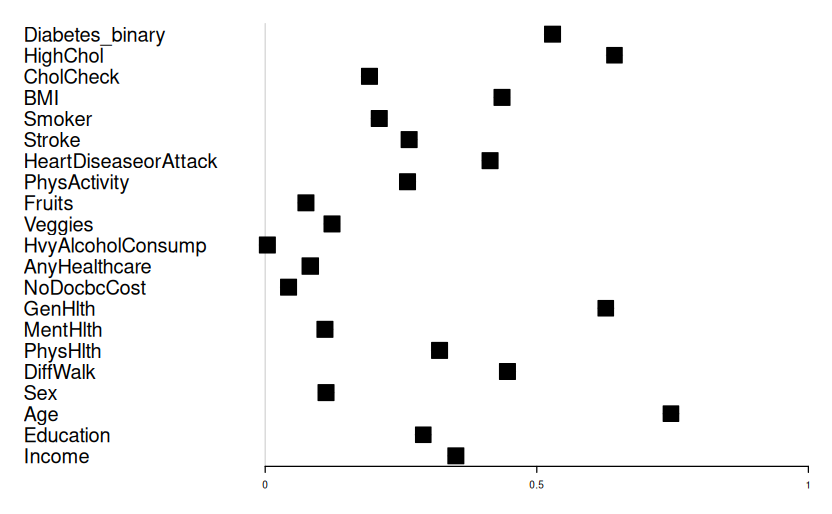

```r
cls <- colnames(data)
cls <- cls[cls != "HighBP"]
base_imb <- as.data.frame(stddiff.numeric(data, vcol=cls, gcol="HighBP"))

forestplot(
  labeltext = cls,
  mean=base_imb$stddiff,
  lower=base_imb$stddiff.l,
  upper=base_imb$stddiff.u
)
```

## Compute Propensity Scores

Lets fix the imbalance using propensity scores. Fit logistic regression model of the treatment on the covariates. First lets find the covariates using the backdoor criterion to get the adjustment set from Daggity. These are the minimum adjustment sets:

- Age, BMI, Fruits, Sex, Smoker, Veggies
- Age, BMI, HighChol, PhysActivity, Smoker
- **Age, BMI, PhysActivity, Sex, Smoker**

Lets choose the last one to work with.

```r
# + GenHlth + HighChol
mdl <- glm(HighBP ~ Age + BMI + PhysActivity + Sex + Smoker, data = data, family="binomial")
summary(mdl)
```

```
Call:
glm(formula = HighBP ~ Age + BMI + PhysActivity + Sex + Smoker,
    family = "binomial", data = data)

Coefficients:
              Estimate Std. Error z value Pr(>|z|)
(Intercept)  -0.337801   0.019658  -17.18   <2e-16 ***
Age           0.855380   0.009490   90.13   <2e-16 ***
BMI           0.556653   0.009357   59.49   <2e-16 ***
PhysActivity -0.339097   0.019134  -17.72   <2e-16 ***
Sex           0.258505   0.016539   15.63   <2e-16 ***
Smoker        0.239122   0.016518   14.48   <2e-16 ***
---
Signif. codes:  0 ‘***’ 0.001 ‘**’ 0.01 ‘*’ 0.05 ‘.’ 0.1 ‘ ’ 1

(Dispersion parameter for binomial family taken to be 1)

    Null deviance: 102404  on 74999  degrees of freedom
Residual deviance:  87502  on 74994  degrees of freedom
AIC: 87514

Number of Fisher Scoring iterations: 4
```

Now get propensity scores (probability of receiving the treatement given the covariates) by transforming the log odds ratios predicted by the logtistic regression model to probabilities.

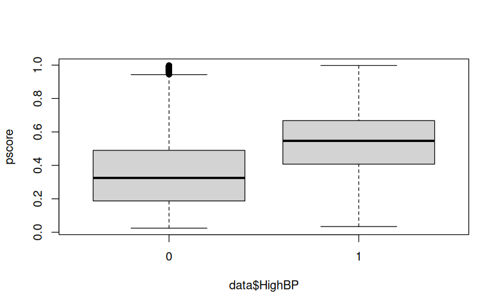

```r
pscore_logit <- predict( mdl )
pscore <- exp(pscore_logit) / (1+exp(pscore_logit))

boxplot(pscore ~ data$HighBP)
```

```r
wgt <- 1/pscore
wgt[!data$HighBP] <- 1/(1-pscore[!data$HighBP])
summary( lm( Diabetes_binary ~ HighBP, data, weights=pscore ) )
```

```
Call:
lm(formula = Diabetes_binary ~ HighBP, data = data, weights = pscore)

Weighted Residuals:
     Min       1Q   Median       3Q      Max
-0.27828 -0.16783 -0.05781 -0.03517  0.90588

Coefficients:
            Estimate Std. Error t value Pr(>|t|)
(Intercept) 0.089391   0.002037   43.89   <2e-16 ***
HighBP      0.189249   0.002789   67.86   <2e-16 ***
---
Signif. codes:  0 ‘***’ 0.001 ‘**’ 0.01 ‘*’ 0.05 ‘.’ 0.1 ‘ ’ 1

Residual standard error: 0.2492 on 74998 degrees of freedom
Multiple R-squared:  0.05785,   Adjusted R-squared:  0.05784
F-statistic:  4605 on 1 and 74998 DF,  p-value: < 2.2e-16
```

```r
mm <- matchit(data$HighBP ~ pscore, caliper=0.1)$match.matrix
```

See how many matched rows out of 75k were matched

```r
nrow(mm)
```

```
[1] 32087
```

We failed to find controls for some treatments, so we need to remove them.

```r
mm <- mm[!is.na(mm),,drop=FALSE]
trt <- as.integer(rownames(mm))
ctrl <- as.integer(mm[,1])
dmtch <- data[c(trt,ctrl),]
nrow(mm)
```

```
[1] 24102
```

After filtering out unmatched items we have ~24k matched data points. Now lets check the covariate balance in our new dataset that contains only matched samples.

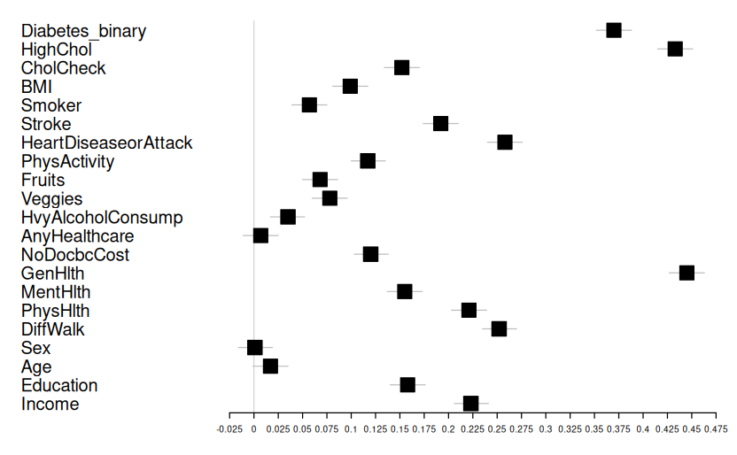

```r
match_imb <-as.data.frame(stddiff.numeric(dmtch, vcol=cls, gcol="HighBP"))
forestplot(
  labeltext = cls,
  mean=match_imb$stddiff,
  lower=match_imb$stddiff.l,
  upper=match_imb$stddiff.u )
```

Hmm this doesn’t seem to have worked as well as one would hope…

Now run regression again on matched data

```r
summary(lm(Diabetes_binary ~ HighBP, dmtch))
```

```
Call:
lm(formula = Diabetes_binary ~ HighBP, data = dmtch)

Residuals:
     Min       1Q   Median       3Q      Max
-0.22330 -0.22330 -0.09103 -0.09103  0.90897

Coefficients:
            Estimate Std. Error t value Pr(>|t|)
(Intercept) 0.091030   0.002305   39.49   <2e-16 ***
HighBP      0.132271   0.003260   40.57   <2e-16 ***
---
Signif. codes:  0 ‘***’ 0.001 ‘**’ 0.01 ‘*’ 0.05 ‘.’ 0.1 ‘ ’ 1

Residual standard error: 0.3579 on 48202 degrees of freedom
Multiple R-squared:  0.03302,   Adjusted R-squared:  0.033
F-statistic:  1646 on 1 and 48202 DF,  p-value: < 2.2e-16
```

Run t-test again

```r
t.test(Diabetes_binary ~ HighBP, dmtch)
```

```
    Welch Two Sample t-test

data:  Diabetes_binary by HighBP
t = -40.57, df = 42834, p-value < 2.2e-16
alternative hypothesis: true difference in means between group 0 and group 1 is not equal to 0
95 percent confidence interval:
 -0.1386614 -0.1258810
sample estimates:
mean in group 0 mean in group 1
     0.09102979      0.22330097
```

# Part 3: Covariate Adjustment

## Step 1: Load DAG with Coefficients

```r
# Bring in the utilities file to access all functions
d <- load_data()
g <- get_dag()
test_for_cycles(g)
```

```
[1] "The Bayesian network is acyclic."
```

```r
# Extract polychoric correlation matrix using lavaan
M <- lavCor(d)

# Use the data, polychoric correlation matrix, and the dag to fit our model
fit <- sem(toString(g, "lavaan"), sample.cov=M, sample.nobs=nrow(d))
```

```r
colnames
```

[output not shown]

```r
# Convert the fitted sem model in lavaan to a daggity dag
fg <- lavaanToGraph(fit, digits=2)

# Save fitted dag with path coefficients
save_to_txt(fg, "FittedDAG.txt")
```

```
Created file: FittedDAG.txt
```

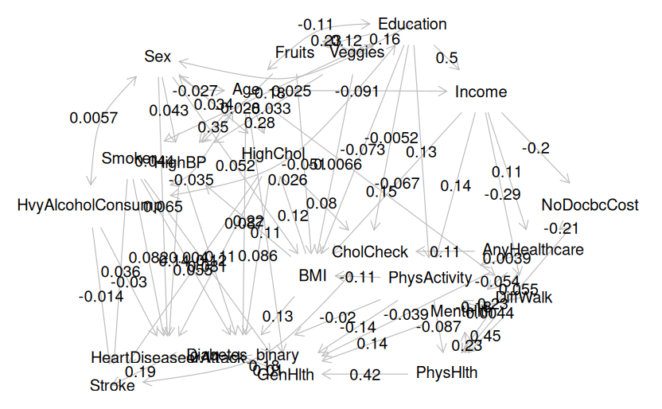

```r
# Extract coordinates from daggity dag
cg <- coordinates(g)
# Apply coordinates to fitted daggity dag
coordinates(fg) <-cg
# Draw resutling daggity dag wtih coefficients
plot(fg, show.coefficients=TRUE)
```

## Step 2: Determine Adjustment Set

Focal relationship is between HighBP and Diabetes. Need to determine the Adjustment Set.

```r
adjustmentSets(fg, "HighBP", "Diabetes_binary")
```

```
{ Age, BMI, GenHlth, HighChol, PhysActivity, Smoker }
{ Age, AnyHealthcare, BMI, HighChol, MentHlth, PhysActivity, PhysHlth, Smoker }
{ Age, AnyHealthcare, BMI, DiffWalk, HighChol, NoDocbcCost, PhysActivity, Smoker }
{ Age, AnyHealthcare, BMI, DiffWalk, HighChol, Income, PhysActivity, Smoker }
{ Age, BMI, GenHlth, PhysActivity, Sex, Smoker }
{ Age, AnyHealthcare, BMI, MentHlth, PhysActivity, PhysHlth, Sex, Smoker }
{ Age, AnyHealthcare, BMI, DiffWalk, NoDocbcCost, PhysActivity, Sex, Smoker }
{ Age, AnyHealthcare, BMI, DiffWalk, Income, PhysActivity, Sex, Smoker }
{ Age, BMI, Education, HighChol, Income, PhysActivity, Smoker }
{ Age, BMI, Education, Income, PhysActivity, Sex, Smoker }
{ Age, BMI, Fruits, Sex, Smoker, Veggies }
```

Here we have lots of adjustment sets, maybe we just pick the smallest one for simplicity (the first one).

## Step 3: Do Logistic Regression on Unadjusted and Adjusted Hand Crafted Network

Unadjusted:

```r
coef(glm(Diabetes_binary ~ HighBP, d, family="binomial"))
```

```
(Intercept)      HighBP
  -2.745317    1.616919
```

```r
confint(glm(Diabetes_binary ~ HighBP, d, family="binomial"))
```

```
                2.5 %   97.5 %
(Intercept) -2.767011 -2.72376
HighBP       1.591297  1.64263
```

Adjusted:

```r
m<-glm(Diabetes_binary ~ HighBP + Age + BMI + GenHlth + HighChol + PhysActivity + Smoker, d, family="binomial")
coef(m)[1:2]
```

```
(Intercept)      HighBP
 -2.7234171   0.7908522
```

```r
confint(glm(Diabetes_binary ~ HighBP + Age + BMI + GenHlth + HighChol + PhysActivity + Smoker, d, family="binomial"))
```

```
                     2.5 %      97.5 %
(Intercept)  -2.7593464984 -2.68764000
HighBP        0.7622274874  0.81953587
Age           0.4128348710  0.44410165
BMI           0.3926171516  0.41557606
GenHlth.L     1.7897128121  1.88658530
GenHlth.Q    -0.3653241975 -0.28323232
GenHlth.C    -0.1220463095 -0.05724590
GenHlth^4     0.0005067336  0.04857708
HighChol      0.5693941851  0.62203059
PhysActivity -0.0992388613 -0.04474986
Smoker        0.0006631143  0.05085210
```

For unadjusted we see a larger effect of 1.62 and for adjusted we see a lower effect of 0.79.

Need to generate confidence intervals or something like this. Also test with different adjustment sets.